# Deploy infrastructure with the Terraform Cloud Kubernetes Operator v1

- 15min
- |
- HCP Terraform
- Terraform

Warning

Version 1 of the HCP Terraform Operator for Kubernetes is **deprecated** and no longer maintained. Refer to the Deploy infrastructure with the HCP Terraform Operator v2 tutorial to get started with version 2 of the operator.

The HCP Terraform Operator for Kubernetes (Operator) allows you to manage the lifecycle of cloud and on-prem infrastructure through a single Kubernetes custom resource.

You can create application-related infrastructure from a Kubernetes cluster by adding the Operator to your Kubernetes namespace. The Operator uses a Kubernetes Custom Resource Definition (CRD) to manage HCP Terraform workspaces. These workspaces execute an HCP Terraform run to provision Terraform modules. By using HCP Terraform, the Operator leverages its proper state handling and locking, sequential execution of runs, and established patterns for injecting secrets and provisioning resources.

[figure not shown]

In this tutorial, you will configure and deploy the Operator to a Kubernetes cluster and use it to create an HCP Terraform workspace. You will also use the Operator to provision a message queue that the example application needs for deployment to Kubernetes.

## Prerequisites

The tutorial assumes some basic familiarity with Kubernetes and `kubectl`.

You should also be familiar with:

- **The Terraform workflow** — All Get Started tutorials
- **HCP Terraform** — All Get Started with HCP Terraform tutorials

For this tutorial, you will need:

- An [HCP Terraform](https://app.terraform.io/session?utm_source=learn) account
- [`kubectl`](https://kubernetes.io/docs/tasks/tools/install-kubectl/)
- An [AWS account](https://aws.amazon.com/free/) and AWS Access Credentials

  Note

  This tutorial will provision resources that qualify under the [AWS free-tier](https://aws.amazon.com/free/). If your account doesn't qualify under the AWS free-tier, we're not responsible for any charges that you may incur.

### Install and configure `kubectl`

To install the `kubectl` (Kubernetes CLI), follow [these instructions](https://kubernetes.io/docs/tasks/tools/install-kubectl/) or choose a package manager based on your operating system.

Use the package manager [`homebrew`](https://formulae.brew.sh/) to install `kubectl`.

```
$ brew install kubernetes-cli
```

Use the package manager [`Chocolatey`](https://chocolatey.org/) to install `kubectl`.

```
$ choco install kubernetes-cli
```

You will also need a sample `kubectl` config. We recommend using `kind` to provision a local Kubernetes cluster and using that config for this tutorial.

Use the package manager [`homebrew`](https://formulae.brew.sh/) to install kind.

```
$ brew install kind
```

Use the package manager [`Chocolatey`](https://chocolatey.org/) to install kind.

```
$ choco install kind
```

Then, create a kind Kubernetes cluster called `terraform-learn`.

```
$ kind create cluster --name terraform-learn
Creating cluster "terraform-learn" ...
 ✓ Ensuring node image (kindest/node:v1.20.2) 🖼
 ✓ Preparing nodes 📦
 ✓ Writing configuration 📜
 ✓ Starting control-plane 🕹️
 ✓ Installing CNI 🔌
 ✓ Installing StorageClass 💾
Set kubectl context to "kind-terraform-learn"
You can now use your cluster with:

kubectl cluster-info --context kind-terraform-learn

Have a question, bug, or feature request? Let us know! https://kind.sigs.k8s.io/#community 🙂
```

Verify that your cluster exists by listing your kind clusters.

```
$ kind get clusters
terraform-learn
```

Then, point `kubectl` to interact with this cluster.

```
$ kubectl cluster-info --context kind-terraform-learn
Kubernetes master is running at https://127.0.0.1:32769
KubeDNS is running at https://127.0.0.1:32769/api/v1/namespaces/kube-system/services/kube-dns:dns/proxy

To further debug and diagnose cluster problems, use 'kubectl cluster-info dump'.
```

## Clone repository

In your terminal, clone the [Learn Terraform Kubernetes Operator repository](https://github.com/hashicorp-education/learn-terraform-kubernetes-operator).

```
$ git clone https://github.com/hashicorp-education/learn-terraform-kubernetes-operator
```

Navigate into the `v1` directory in the repository.

```
$ cd learn-terraform-kubernetes-operator/v1
```

This repository contains the following files.

```
.
├── aws-sqs-test
│   ├── Dockerfile
│   └── message.sh
├── operator
│   ├── application.yml
│   ├── configmap.yml
│   └── workspace.yml
├── main.tf
└── terraform.tfvars.example
├── credentials.example
```

- The root of this directory contains the Terraform configuration for a Kubernetes namespace and the Operator helm chart.
- The `operator` directory contains the Kubernetes `.yml` files that you will use to create an HCP Terraform workspace using the Operator.
- The `aws-sqs-test` directory contains the files that build the Docker image that tests the message queue. This is provided as reference only. You will use an image from DockerHub to test the message queue.

## Configure the Operator

The Operator must have access to HCP Terraform and your AWS account. It also needs to run in its own Kubernetes namespace. Below you will configure the Operator and deploy it into your Kubernetes cluster using a Terraform configuration that we have provided for you.

### Configure HCP Terraform access

The Operator must authenticate to HCP Terraform. To do this, you must create an HCP Terraform Team API token, then add it as a secret for the Operator to access.

First, sign into your HCP Terraform account, then select "Settings" -> "Teams".

[figure not shown]

If you are using a free tier, you will only find one team called "owners" that has full access to the API. Click on "owners".

[figure not shown]

Click on the **API tokens** option in the left navigation, and then choose the **Team Tokens** tab.

Click **Create a team token**. Under **Team**, choose your team name and choose an **Expiration** of **30 days**. Click **Create**.

Click **Copy token** to copy the token string. Store this token in a secure place as HCP Terraform will not display it again. You will use this token in the next step.

Warning

The Team token has global privileges. Ensure that the Kubernetes cluster using this token has proper role-based access control to limit access to the secret, or store it in a secret manager with access control policies.

Copy the contents of `credentials.example` into a new file named `credentials`.

```
$ cp credentials.example credentials
```

Then replace `TERRAFORM_CLOUD_API_TOKEN` with the HCP Terraform Teams token you previously created.

```
credentials app.terraform.io {
  token = "TERRAFORM_CLOUD_API_TOKEN"
}
```

### Explore Terraform configuration

The `main.tf` file has Terraform configuration that will deploy the Operator into your Kubernetes cluster. It includes:

- **A Kubernetes Namespace.** This is where you will deploy the Operator, Secrets, and Workspace custom resource.

  ```
  resource "kubernetes_namespace" "edu" {
    metadata {
      name = "edu"
    }
  }
  ```

- **A `terraformrc` generic secret for your TFC Teams token.** This is the default secret name the Operator uses for your HCP Terraform credentials. The secret will contain the contents of your `credentials` file.

  ```
  resource "kubernetes_secret" "terraformrc" {
    metadata {
      name = "terraformrc"
      namespace = kubernetes_namespace.edu.metadata[0].name
    }

    data = {
      "credentials" = file("${path.cwd}/credentials")
    }
  }
  ```

- **A generic secret named `workspacesecrets` containing your AWS credentials.** In addition to the HCP Terraform Teams token, HCP Terraform needs your cloud provider credentials to create infrastructure. This configuration adds your credentials to the namespace, which will pass them to HCP Terraform. You will add the credential values as variables in a later step.

  ```
  resource "kubernetes_secret" "workspacesecrets" {
    metadata {
      name = "workspacesecrets"
      namespace = kubernetes_namespace.edu.metadata[0].name
    }

    data = {
      "AWS_ACCESS_KEY_ID"     = var.aws_access_key_id
      "AWS_SECRET_ACCESS_KEY" = var.aws_secret_access_key
    }
  }
  ```

- **The Operator Helm Chart.** This is the configuration for the Operator, which is dependent on the `terraformrc` and `workspacesecrets` secrets.

  ```
  resource "helm_release" "operator" {
    name       = "terraform-operator"
    repository = "https://helm.releases.hashicorp.com"
    chart      = "terraform"

    namespace = kubernetes_namespace.edu.metadata[0].name

    depends_on = [
      kubernetes_secret.terraformrc,
      kubernetes_secret.workspacesecrets
    ]
  }
  ```

In order to use this configuration, you need to define the variables that authenticate to the `kind` cluster and AWS.

Run the following command. It will generate a `terraform.tfvars` file with your `kind` cluster configuration.

```
$ kubectl config view --minify --flatten --context=kind-terraform-learn -o go-template-file=tfvars.gotemplate > terraform.tfvars
```

Open `terraform.tfvars` and add your AWS credentials in `aws_access_key_id` and `aws_secret_access_key` respectively.

You should end up with something similar to the following.

```
host                   = "https://127.0.0.1:32768"
client_certificate     = "LS0tLS1CRUdJTiB..."
client_key             = "LS0tLS1CRUdJTiB..."
cluster_ca_certificate = "LS0tLS1CRUdJTiB..."
aws_access_key_id      = "REDACTED"
aws_secret_access_key  = "REDACTED"
```

Warning

Do not commit sensitive values into version control. The `.gitignore` file found in this repository ignores all `.tfvars` files. Include it in all of your future Terraform repositories.

### Deploy the Operator

Now that you have defined the variables, you are ready to create the Kubernetes resources.

Initialize your configuration.

```
$ terraform init
```

Apply your configuration. Remember to confirm your apply with a `yes`.

```
$ terraform apply
## ...
kubernetes_namespace.edu: Creating...
kubernetes_namespace.edu: Creation complete after 0s [id=edu]
kubernetes_secret.terraformrc: Creating...
kubernetes_secret.workspacesecrets: Creating...
kubernetes_secret.terraformrc: Creation complete after 0s [id=edu/terraformrc]
kubernetes_secret.workspacesecrets: Creation complete after 0s [id=edu/workspacesecrets]
helm_release.operator: Creating...
helm_release.operator: Still creating... [10s elapsed]
helm_release.operator: Creation complete after 14s [id=terraform-operator]

Apply complete! Resources: 4 added, 0 changed, 0 destroyed.
```

Create an environment variable named `NAMESPACE` and set it to `edu`.

```
$ export NAMESPACE=edu
```

The Operator runs as a pod in the namespace. Verify the pod is running.

```
$ kubectl get -n $NAMESPACE pod
NAME                                                             READY   STATUS     RESTARTS   AGE
terraform-1613122278-terraform-sync-workspace-5c8695bf59-pgbpm   1/1     Running    0          108s
```

In addition to deploying the Operator, the Helm chart adds a Workspace custom resource definition to the cluster.

```
$ kubectl get crds
NAME                          CREATED AT
workspaces.app.terraform.io   2021-02-12T09:31:19Z
```

## Explore workspace specification

Now you are ready to create infrastructure using the Operator.

First, navigate to the `operator` directory.

```
$ cd operator
```

Open `workspace.yml`, the workspace specification, and customize it with your HCP Terraform organization name. The workspace specification both creates an HCP Terraform workspace, and uses it to deploy your application's required infrastructure.

This workspace specification is equivalent to the following Terraform configuration.

```
module "queue" {
  source = "terraform-aws-modules/sqs/aws"
  version = "2.0.0"
  name = var.name
  fifo_queue = var.fifo_queue
}
```

You can find the following items in `workspace.yml`, which you use to apply the Workspace custom resource to a Kubernetes cluster.

- **The workspace name suffix.** The workspace name is a combination of your namespace and `metadata.name` (in this case: `edu-greetings`)

  ```
  metadata:
    name: greetings
  ```

- **The HCP Terraform organization.** This organization must match the one you generate the Teams token for. Replace `ORGANIZATION_NAME` with your HCP Terraform organization name.

  ```
  spec:
    organization: ORGANIZATION_NAME
  ```

- **The file path to secrets on the Operator.** By default, the Operator helm chart mounts your `workspacesecrets` secrets to `/tmp/secrets`.

  ```
  spec:
    organization: ORGANIZATION_NAME
    secretsMountPath: '/tmp/secrets'
  ```

- **A Terraform module.** This Workspace specification uses the AWS SQS module.

  ```
  module:
    source: 'terraform-aws-modules/sqs/aws'
    version: '2.0.0'
  ```

- **Input variables.** For variables that must be passed to the module, the variable key in the specification must match the name of the module variable. You can set whether a variable is sensitive or an environment variable, and the variable's value using [ConfigMaps](https://kubernetes.io/docs/concepts/configuration/configmap/). We have set reasonable defaults for these values which you will review in a later step.

- **Outputs you would like to find in the Kubernetes status.** The example maps [`this_sqs_queue_id`](https://registry.terraform.io/modules/terraform-aws-modules/sqs/aws/latest?tab=outputs) to an output named `url` .

  ```
  outputs:
    - key: url
      moduleOutputName: this_sqs_queue_id
  ```

### Explore `configmap.yml`

In `workspace.yml`, the `AWS_DEFAULT_REGION` variable is defined by a ConfigMap named `aws-configuration`.

Open `configmap.yml`. Here you will find the specifications for the `aws-configuration` ConfigMap.

```
apiVersion: v1
kind: ConfigMap
metadata:
  name: aws-configuration
data:
  region: us-east-1
```

## Create the message queue

Apply the ConfigMap specifications to the namespace.

```
$ kubectl apply -n $NAMESPACE -f configmap.yml
configmap/aws-configuration created
```

Then, apply the Workspace specifications to the namespace.

```
$ kubectl apply -n $NAMESPACE -f workspace.yml
workspace.app.terraform.io/greetings created
```

Debug the Operator by accessing its logs and checking if the workspace creation ran into any errors.

```
$ kubectl logs -n $NAMESPACE $(kubectl get pods -n $NAMESPACE --selector "component=sync-workspace" -o jsonpath="{.items[0].metadata.name}")
## ...
{"level":"info","ts":1613124305.9530287,"logger":"terraform-k8s","msg":"Run incomplete","Organization":"hashicorp-training","RunID":"run-xxxxxxxxxxxxxxxx","RunStatus":"applying"}
{"level":"info","ts":1613124306.7574627,"logger":"terraform-k8s","msg":"Checking outputs","Organization":"hashicorp-training","WorkspaceID":"ws-xxxxxxxxxxxxxxxx","RunID":"run-xxxxxxxxxxxxxxxx"}
{"level":"info","ts":1613124307.0337532,"logger":"terraform-k8s","msg":"Updated outputs","Organization":"hashicorp-training","WorkspaceID":"ws-xxxxxxxxxxxxxxxx"}
{"level":"info","ts":1613124307.0339234,"logger":"terraform-k8s","msg":"Updating secrets","name":"greetings-outputs"}
```

View the Terraform configuration uploaded to HCP Terraform. The Terraform configuration includes the module's source, version, and inputs.

```
$ kubectl describe -n $NAMESPACE configmap greetings
Name:         greetings
Namespace:    edu
Labels:       <none>
Annotations:  <none>

Data
====
terraform:
----
terraform {
           backend "remote" {
             organization = "hashicorp-training"

             workspaces {
               name = "edu-greetings"
             }
           }
         }
         variable "name" {}
         variable "fifo_queue" {}
         output "url" {
           value = module.operator.this_sqs_queue_id
         }
         module "operator" {
           source = "terraform-aws-modules/sqs/aws"
           version = "2.0.0"
           name = var.name
           fifo_queue = var.fifo_queue
         }
Events:  <none>
```

Check the status of the workspace via kubectl or the HCP Terraform web UI to determine the run status, outputs, and run identifiers.

The Workspace custom resource reflects that the run was applied and updates its corresponding outputs in the status.

[output not shown]

[figure not shown]

In addition to the workspace status, the Operator creates a Kubernetes Secret containing the outputs of the HCP Terraform workspace. The Secret is formatted `<workspace_name>-outputs`.

```
$ kubectl describe -n $NAMESPACE secrets greetings-outputs
Name:         greetings-outputs
Namespace:    edu
Labels:       <none>
Annotations:  <none>

Type:  Opaque

Data
====
url:  60 bytes
```

### Verify message queue

Now that you have deployed the queue, you will now send and receive messages on the queue.

The `application.yml` contains a spec that runs a containerized application in your `kind` cluster. That app calls a script called `message.sh`, which sends and receives messages from the queue, using the same AWS credentials that the Operator used.

To give the script access to the queue's location, the `application.yml` spec creates a new environment variable named `QUEUE_URL`, and sets it to the Kubernetes Secret containing the queue url from the HCP Terraform workspace output.

```
- name: QUEUE_URL
  valueFrom:
    secretKeyRef:
      name: greetings-outputs
      key: url
```

Tip

If you mount the Secret as a volume, rather than project it as an environment variable, you can update that Secret without redeploying the app.

Open `aws-sqs-test/message.sh`. This bash script tests the message queue. To access the queue, it creates environment variables with your AWS credentials and the queue URL. Since HCP Terraform outputs from the Kubernetes Secret contain double quotes, the script strips the double quotes from the output (`QUEUE_URL`) to ensure the script works as expected.

```
## ...
export SQS_URL=$(eval echo $QUEUE_URL | sed 's/"//g')
## ...
```

Deploy the job and examine the logs from the pod associated with the job.

```
$ kubectl apply -n $NAMESPACE -f application.yml
job.batch/greetings created
```

View the job's logs.

```
$ kubectl logs -n $NAMESPACE $(kubectl get pods -n $NAMESPACE --selector "app=greetings" -o jsonpath="{.items[0].metadata.name}")
https://sqs.us-east-1.amazonaws.com/REDACTED/greetings.fifo
sending a sdfgsdf message to queue https://sqs.us-east-1.amazonaws.com/REDACTED/greetings.fifo
{
    "MD5OfMessageBody": "fc3ff98e8c6a0d3087d515c0473f8677",
    "SequenceNumber": "xxxxxxxxxxxxxxxx",
    "MessageId": "xxxxxxxxxxxxxxxx"
}
reading a message from queue https://sqs.us-east-1.amazonaws.com/656261198433/greetings.fifo
{
    "Messages": [
        {
            "Body": "hello world!",
            "ReceiptHandle": "xxxxxxxxxxxxxxxx",
            "MD5OfBody": "fc3ff98e8c6a0d3087d515c0473f8677",
            "MessageId": "xxxxxxxxxxxxxxxx"
        }
    ]
}
```

## Change the queue name

Once your infrastructure is running, you can use the Operator to modify it. Update the `workspace.yml` file to change the queue's name, and the type of the queue from FIFO to standard.

```
# workspace.yml
 apiVersion: app.terraform.io/v1alpha1
 kind: Workspace
 metadata:
  name: greetings
 spec:
    ## ...
  variables:
    - key: name
-    value: greetings.fifo
+     value: greetings
    - key: fifo_queue
-     value: "true"
+     value: "false"
    ## ...
```

Changing inline, non-sensitive variables, module source, and module version in the Kubernetes Workspace custom resource will trigger a new run in the HCP Terraform workspace. Changing sensitive variables or variables with ConfigMap references will not trigger updates or runs in HCP Terraform.

Apply the updated workspace configuration. The Terraform Operator retrieves the configuration update, pushes it to HCP Terraform, and executes a run.

```
$ kubectl apply -n $NAMESPACE -f workspace.yml
workspace.app.terraform.io/greetings configured
```

Examine the run for the workspace in the HCP Terraform UI. The plan indicates that HCP Terraform replaced the queue.

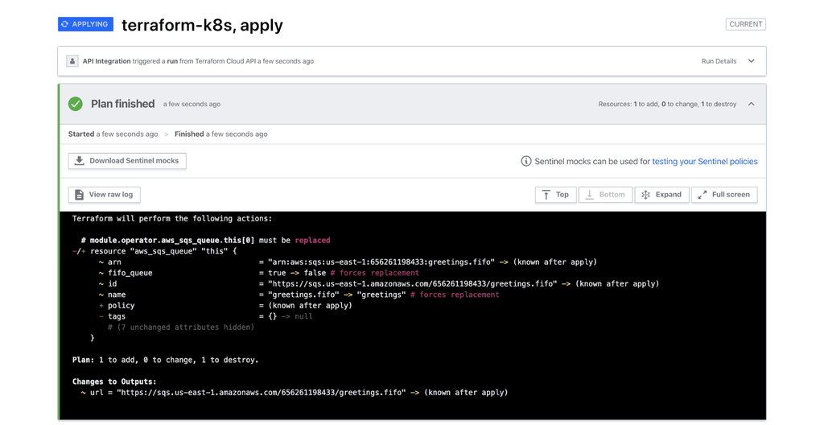

You can audit updates to the workspace from the Operator through HCP Terraform, which maintains a history of runs and the current state.

## Clean up resources

Now that you have created and modified an HCP Terraform workspace using the Operator, delete the workspace.

### Delete workspace

Delete the Workspace custom resource.

```
$ kubectl delete -n $NAMESPACE workspace greetings
workspace.app.terraform.io "greetings" deleted
```

You may notice that the command hangs for a few minutes. This is because the Operator executes a [finalizer](https://github.com/kubernetes-sigs/kubebuilder/blob/master/docs/book/src/reference/using-finalizers.md), a pre-delete hook. It executes a `terraform destroy` on workspace resources and deletes the workspace in HCP Terraform.

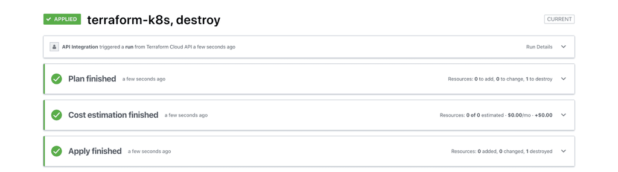

Once the finalizer completes, Kubernetes will delete the Workspace custom resource.

### Delete resources and `kind` cluster

Navigate to the `v1` directory.

```
$ cd ..
```

Destroy the namespace, secrets and the Operator. Remember to confirm the destroy with a yes.

```
$ terraform destroy
```

Finally, delete the `kind` cluster.

```
$ kind delete cluster --name terraform-learn
Deleting cluster "terraform-learn" ...
```

## Next steps

Congrats! You have configured and deployed the Operator to a Kubernetes namespace, explored the Workspace specification, and created a Terraform workspace using the Operator. In doing so, you deployed a message queue from `kubectl`. This pattern can extend to other application infrastructure, such as DNS servers, databases, and identity and access management rules.

Visit the following resources to learn more about the HCP Terraform Operator for Kubernetes.

- To learn more about the Operator and its design, check out the hashicorp/terraform-k8s repository.
- To learn more about the Operator helm chart, check out the hashicorp/terraform-helm repository. You can also view [example Workspace specifications](https://github.com/hashicorp/terraform-helm/tree/master/example) here too.
- To watch a demo of the Operator, visit [Demo: GitOps configuration using the HCP Terraform Operator for Kubernetes](https://www.youtube.com/watch?v=h89maGMrRXY) or [Demo: HashiCorp Terraform Operator for Kubernetes](https://www.youtube.com/watch?v=4MJF-enC3Us).
- To discover more about managing Kubernetes with Terraform, review the Hashicorp Kubernetes tutorials.